# Use of polar plots and friends

Ricardo Energy & Environment / University of York

David Carslaw and Hao Wu

7–9 October 2019

# 1 Bivariate polar plots

## 1.1 Introduction

Bivariate polar plots are an effective way in which to gain information about sources of air pollution where wind direction and wind speed can reveal information about the character of sources. They show how concentrations vary by wind direction and wind speed, shown in polar coordinates. In addition, they show the concentration as a smoothed surface. Because pollutant concentrations vary in important ways when plotted against wind direction *and* speed they can provide insights into the character of the emission sources (Carslaw et al. 2006; Uria-Tellaetxe and Carslaw 2014; Carslaw and Beevers 2013; Grange, Lewis, and Carslaw 2016).

In these plots the radial axis is by default wind speed — changing from zero wind speed in the centre and increasing outwards. The `openair` manual and associated papers provide much more detail on their purpose and development.

It should be stressed that the radial axis does not have to be wind speed. It could be temperature or a measure of atmospheric stability, or indeed any other continuous variable. **The key point is that the variable on the radial axis in some way helps to differentiate between different sources types**. A better idea of these ideas are shown in the examples below.

# 2 Source types

## 2.1 Area source

Area sources such as large urban areas tend to be characterised by having highest concentrations under low wind speed conditions i.e. stable atmospheres. In the plot below there is a clear ‘bull’s eye’ effect where concentrations are much higher under low wind speed conditions from all directions. In the plot below a large area source (representing an urban area such as London) was modelled using the [ADMS model](http://www.cerc.co.uk/environmental-software/ADMS-model.html).

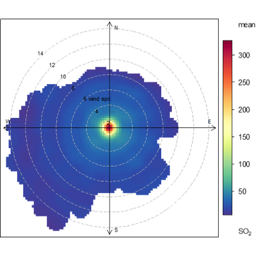

It is easy to see whether the modelled behaviour above is replicated by real atmospheric measurements. As an example 1-year of hourly data can be analysed from the North Kensington urban background site in inner London. The data are imported using the `importAURN` function.

It is easy to import the data using `openair` using the `importAURN` or `importKCL` functions (provides access to data from the Defra Automatic Urban and Rural Network). Type `?importAURN` to find out more about this (and other) sites. Note that wind speed, wind direction and temperature may also be imported (for data from around 2010). These meteorological data are not based on surface measurements but derived from the WRF regional model.

The `importAURN` and `importKCL` functions show how easy it can be to import air pollution data. In both cases data in databases (SQL Server of MySQL) have been processed using R to produce annual .RData files, which are then stored on a webserver. However, the `saqgetr` package provides much more air quality data from around Europe and provides access to Spanish data.

> **Take time to have a look at Spanish air quality sites using the `saqgetr` package. Choose site(s) that are likely to be representative of urban background sites in large cities.**

The plot based on urban measurements below shows the same sort of pattern as the modelled version above i.e. highest concentrations at low wind speeds.

```r
library(worldmet)
library(dplyr)
library(openair)
```

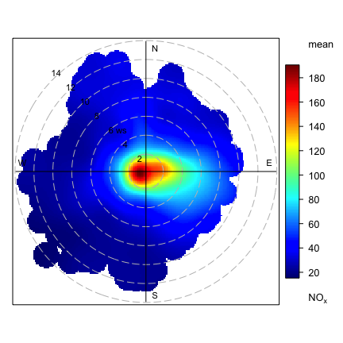

```r
# import AQ measurements
kc1 <- importAURN(site = "kc1", year = 2003)

# import met data (default site at Heathrow is OK, so just need year)
met <- importNOAA(year = 2003)

# merge data sets
kc1 <- inner_join(kc1, met, by = "date")

# make a plot
polarPlot(kc1, pollutant = "nox", cols = "jet")
```

## 2.2 Point (chimney stack) source

Point source emissions released at height and with buoyancy (because the plume is hot) can show a very different pattern on polar plots.

In this case a tall (250m) chimney stack was modelled with a receptor 1 km from the source. This type of source is typical of a large power station.

In this case the ADMS model shows a very different pattern of concentration compared to roads or large volume sources. Highest concentrations are observed under high wind speed conditions, which is opposite to the behaviour of a source representing a large urban area of ground-level sources such as road vehicles and domestic combustion.

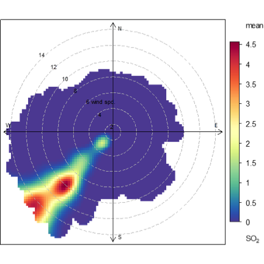

We can consider these plume effects in more detail to see how a plume can be brought down to ground level under higher wind speed conditions. The plot below shows the plume centreline for a tall stack (typical of a large power station) under two conditions: 2 m s<sup>-1</sup> and 12 m s<sup>-1</sup>. The figure clearly shows the lower mean plume height under higher wind speed conditions. In addition, under windy conditions there will be more mechanical turbulence generated that will also aid plume mixing.

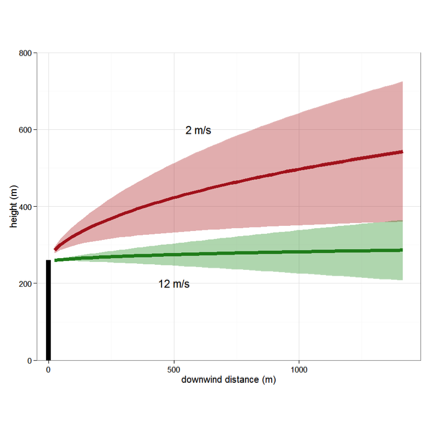

Again, it is possible to consider real measurements to see if similar patterns are observed. The North Kensignton site is affected by power stations to the east of London, which is most clear for SO<sub>2</sub> concentrations…

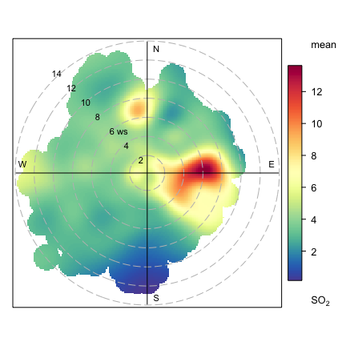

```r
polarPlot(kc1, pollutant = "so2")
```

Large power stations are not the only source that could results in high concentrations under high wind speed conditions. For other pollutants, other processes can be important. For example, the suspension (or re-suspension) of particulate can occur under high wind speed conditions, as can sea-salt aerosol. Non-local sources e.g. secondary particulate and the long-range transport of dust can also be observed under high wind speed conditions.

## 2.3 Road or line sources

The pattern for road sources can vary a lot but is often shown as being clearly offset from the axes, as shown in the plot below where the road is to the south. For this particular example the road is assumed to be in open, flat terrain and is not affected by complex dispersion.

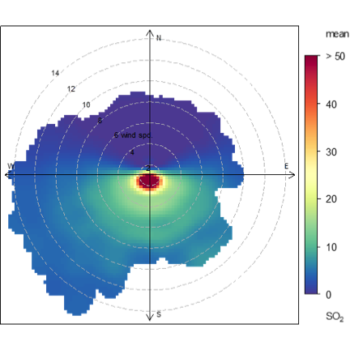

The pattern can however be highly complex, if (for example) the road is located in a street canyon. In these conditions, the apparent location of the source can be opposite to that expected because of recirculation of the plume in the canyon. Marylebone Road in central London is a good example of a ‘classical’ street canyon situation. Indeed, the data that comes with **openair** (`mydata`) is about 8 years of data from Marylebone Road, so it is easy to plot:

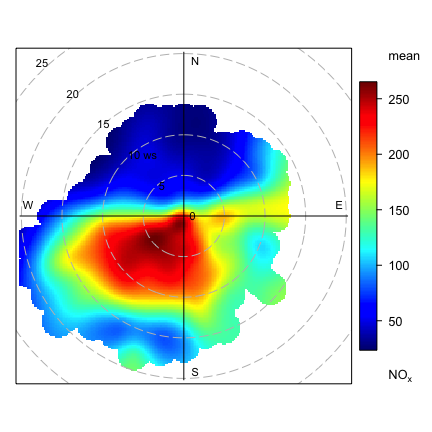

```r
polarPlot(mydata, pollutant = "nox",
          col = "jet")
```

The Marylebone Road site is on the south side of the street (see [here](https://www.google.co.uk/maps/@51.5226426,-0.1543565,3a,75y,238.15h,88.24t/data=!3m6!1e1!3m4!1sH9Nw9VVu4pFVRGrrI8Sx5Q!2e0!7i13312!8i6656)). However, the highest concentrations are wind the wind is coming from the south i.e. from the site to the road and not the other way around (see Figure [here](https://en.wikipedia.org/wiki/Street_canyon#/media/File:A_wind_vortex_inside_a_street_canyon.png)).

## 2.4 Example of isoprene at Harwell

Isoprene is an interesting example to consider because the source is mostly biogenic in origin — although some isoprene is also emitted by road vehicles. The Harwell site is one of the few in the UK that measures hydrocarbons along with other species. The site itself is in rural Oxfordshire and is funded by Defra.

```r
hc <- importAURN("har", 2013, hc = TRUE)

# import met data from nearby site (Benson)
met <- importNOAA(code = "036580-99999", year = 2013)

# merge AQ and met but don't use modelled ws and wd
hc <- inner_join(
  select(hc, -ws, -wd),
  met,
  by = "date"
)

# lots of data, so just print variable names
glimpse(hc)
```

```
## Observations: 8,760
## Variables: 70
## $ date        <dttm> 2013-01-01 00:00:00, 2013-01-01 01:00:00, 2013-01-0…
## $ code.x      <fct> HAR, HAR, HAR, HAR, HAR, HAR, HAR, HAR, HAR, HAR, HA…
## $ site        <fct> Harwell, Harwell, Harwell, Harwell, Harwell, Harwell…
## $ o3          <dbl> 67.65423, 72.04477, 71.19660, 66.55660, 68.45251, 69…
## $ no2         <dbl> 1.89529, 0.31301, 0.22902, 0.64547, 0.64643, 0.82620…
## $ so2         <dbl> 8.42086, 7.97294, 6.92034, 7.12190, 6.92034, 6.45002…
## $ nox         <dbl> 2.70071, 0.63546, 0.89362, 1.37021, 1.31064, 1.37021…
## $ no          <dbl> 0.52511, 0.21038, 0.43344, 0.47273, 0.43344, 0.35486…
## $ `13bdiene`  <dbl> 0.089808, 0.067356, 0.067356, 0.089808, 0.067356, 0.…
## $ `1butene`   <dbl> 0.209547, 0.162981, 0.139698, 0.162981, 0.139698, 0.…
## $ benzene     <dbl> 0.486450, 0.421590, 0.356730, NA, 0.421590, 0.291870…
## $ c2butene    <dbl> 0.023283, 0.023283, 0.011642, 0.023283, 0.023283, 0.…
## $ ethane      <dbl> 3.417602, 3.093304, 2.843844, 3.517386, 3.118250, 2.…
```

[output cut: 57 more lines]

The polar plot below shows that the highest concentrations of isoprene tend to occur at low wind speeds, especially when the wind direction is from the south.

For ‘fun’ we’ll also try a different colour scheme using the `viridis` package (see [here](https://cran.r-project.org/web/packages/viridis/vignettes/intro-to-viridis.html) for details of the colour schemes. In **openair**, simplified versions of the viridis colour schemes exist for: “viridis”, “plasma”, “magma”, “inferno” and “cividis”.

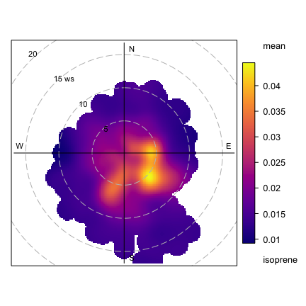

```r
polarPlot(hc, pollutant = "isoprene", col = "plasma")
```

However, the radial axis does not have to be wind speed. In this case it is interesting to use temperature (`air_temp`) for the radial axis. The plot below shows that the highest concentrations of isoprene occur when the temperature is high (and the wind direction is from the south). This behaviour is entire expected from what is known about isoprene emissions i.e. released at higher ambient temperatures.

Also, to demonstrate how to be more flexible with colours, we can take an **openair** colour palette and reverse the ordering of the colours for different effects using the `openColours` function.

```r
my_cols <- rev(openColours("magma", 10))
```

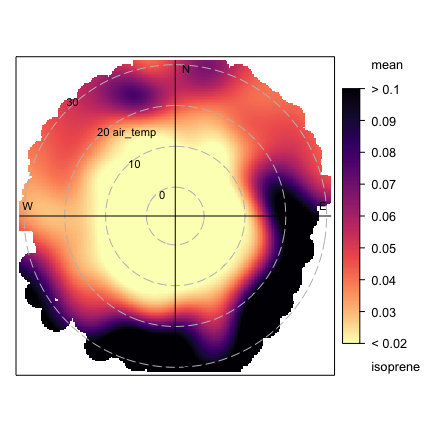

```r
polarPlot(hc, pollutant = "isoprene", x = "air_temp",
          col = my_cols,
          limits = c(0.02, 0.1))
```

> **What do polar plots look like for some interesting sites in Spain — use the `saqgetr` package. It can be interesting to contrast different pollutants at the same site, or between sites.**

# 3 Conditional probability functions

Often the interest in knowing which directions and under which conditions the highest concentrations occur for a species. The *Conditional Probability Function* (CPF) is a useful approach here (Uria-Tellaetxe and Carslaw 2014), see open-access paper [here](https://www.sciencedirect.com/science/article/pii/S1364815214001339). It is usually expressed as the probability that a certain concentration (often a percentile such as the 90th) is exceeded in a given wind sector. In the bivariate (`polarPlot`) case it is the probability that a concentration is exceeded in a given wind-speed/ wind direction interval. In **openair** there are two main functions to plot CPFs: `percentileRose` and `polarPlot`.

The `percentileRose` function will plot the concentration at one or more percentile values by wind direction. For example, a plot of several percentile concentrations of benzene can be made by

```r
percentileRose(
  hc, pollutant = "benzene",
  percentile = c(50, 75, 90, 95), cols = "viridis"
)
```

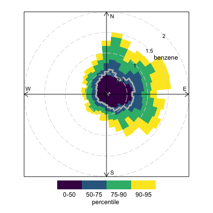

For example, based on the isoprene plot above, we could plot the concentrations in a different way by asking “what is the probability that a concentration exceeds a particular percentile in any wind speed-direction bin?”. This sort of plot can give a clearer indication of the origins of the highest concentration conditions.

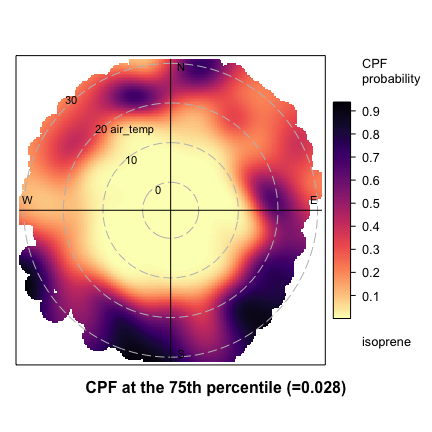

```r
polarPlot(
  hc, pollutant = "isoprene", x = "air_temp",
  statistic = "cpf", percentile = 75,
  cols = my_cols
)
```

> **Take some time to explore the use of the CPF in `polarPlot` with Spanish air quality data. It might be useful for example to consider sites known to be influenced by industrial sources or Saharan dust.**

# 4 Clustering surfaces and investigating clusters

The patterns shown by polar plots often reveal interesting features that warrant further investigation — but how best to identify features? They can be highly influenced by the colour schemes used. One approach is to use cluster analysis applied to the surface to identify areas of common similarities of concentration, wind speed and direction (Carslaw and Beevers 2013).

As an example, we can consider the North Kensington site in London. To make it more interesting, we will focus on conditions where the is a high chance of high concentrations with a percentile value of 90. Try plotting the surface first:

```r
polarPlot(kc1, pollutant = "so2", statistic = "cpf", percentile = 90)
```

[output not shown]

Now we can explore how clustering might partition the surface by considering cluster solutions from 2:5. The plot below shows that a two cluster solution is fine for our purposes and nicely isolates the peak to the east.

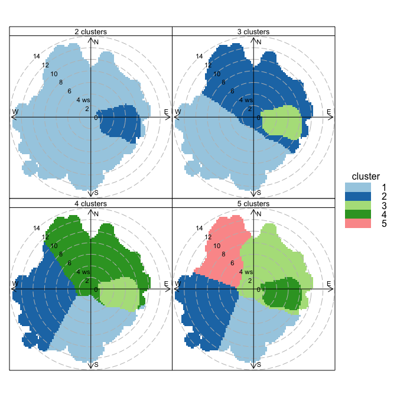

```r
polarCluster(kc1, pollutant = "so2", statistic = "cpf", percentile = 90,
             n.clusters = 2:5)
```

Having decided that a two-cluster solution is what we want, we can carry out further analysis.

```r
clust <- polarCluster(kc1, pollutant = "so2", statistic = "cpf",
                      percentile = 90, n.clusters = 2)
```

[figure not shown]

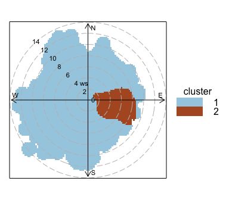

`clust` is an object that returns various things including the original hourly data *and the associated clusters*.

We can have a look at the data and read it into a data frame for further uses. We can retrieve the results of the two-cluster solution as follows.

```r
clust_data <- clust$data

# note column called `cluster`
names(clust_data)
```

```
##  [1] ".id"         "date"        "code.x"      "site"        "co"
##  [6] "pm10"        "no"          "no2"         "nox"         "o3"
## [11] "so2"         "usaf"        "wban"        "code.y"      "station"
## [16] "lat"         "lon"         "elev"        "wd"          "ws"
## [21] "ceil_hgt"    "visibility"  "air_temp"    "dew_point"   "atmos_pres"
## [26] "RH"          "cl_1"        "cl_1_height" "cl_2"        "cl_2_height"
## [31] "cl_3"        "cl_3_height" "cl"          "cluster"
```

Now we can use the data and plot and analyse it by cluster number. What this shows is that cluster 2 (the ‘feature’) has much higher concentrations than cluster 1 (everything else).

```r
group_by(clust_data, cluster) %>%
  summarise(mean = mean(so2, na.rm = TRUE),
            max = max(so2, na.rm = TRUE),
            n = n())
```

```
## # A tibble: 2 x 4
##   cluster  mean   max     n
##   <fct>   <dbl> <dbl> <int>
## 1 1        4.23    40  7145
## 2 2       10.0     80  1494
```

We can explore the temporal variations of these clusters also.

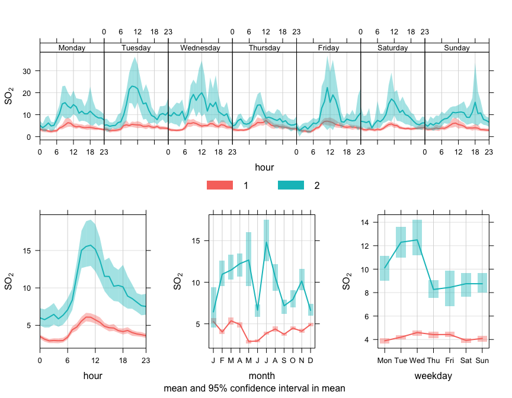

```r
timeVariation(clust_data, pollutant = "so2", group = "cluster")
```

> **Using some of the techniques described above, explore some of the air pollution characteristics at other sites. See if you can explore the results of cluster analysis using other openair plots such as `calendarPlot` and `timeVariation`. With more years of data it can be very useful to plot trends by cluster — something to try…**

# 5 Relationship between two variables

In a further extension to polar plots, it is possible to consider how two variables are related to one another in a bivariate polar plot (Grange, Lewis, and Carslaw 2016). The main idea behind this new approach is that by understanding how two pollutants are related, information can be provided about the nature of the source(s) involved. While it is possible to consider statistics such as the Pearson correlation coefficient, *r*, for measurement data, much greater insight is possible by additionally considering whether there are higher or lower correlations for particular wind speeds and directions. Consider for example two metals emitted at a steelworks — it may well be that the highest correlation between the two metals occurs for very specific wind speeds and directions due to a particular process used to manufacture steel. Considering the correlation using all data may show evidence that two pollutants are correlated but not reveal they only tend to be correlated under some conditions.

A scatter plot of PM<sub>2.5</sub> and PM<sub>10</sub> does show a strong relationship with no obvious issues (see plot below). We might conclude that PM<sub>2.5</sub> and PM<sub>10</sub> are highly correlated under all conditions — but is that true?

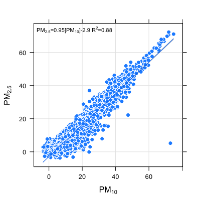

```r
scatterPlot(hc, x = "pm10", y = "pm2.5",
            fill = "dodgerblue", col = "white", pch = 21,
            linear = TRUE)
```

As an example, we can plot the correlation surface between PM<sub>2.5</sub> and PM<sub>10</sub> for the rural Harwell site. The plot below shows that PM<sub>2.5</sub> and PM<sub>10</sub> and very highly correlated for easterly winds, which in this case will almost certainly be due to transboundary contributions and a lot of secondary aerosol.

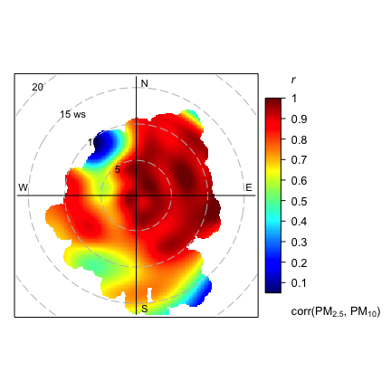

```r
polarPlot(hc, poll = c("pm2.5", "pm10"), statistic = "r", col = "jet")
```

We can explore the relationship further by considering the slope of the regression between PM<sub>2.5</sub> and PM<sub>10</sub>. In this plot there is a clear region where almost all the PM<sub>10</sub> is PM<sub>2.5</sub> (from about zero to 140 degrees).

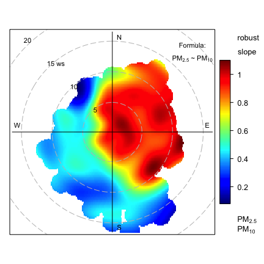

```r
polarPlot(hc, poll = c("pm2.5", "pm10"),
          statistic = "robust_slope",
          col = "jet")
```

We can usefully identify these two regions by applying cluster analysis of the data as before. Two clusters is sufficient to select the two regions.

```r
clust <- polarCluster(hc, poll = c("pm2.5", "pm10"),
                      statistic = "robust_slope",
                      n.clusters = 2,
                      col = "viridis")
```

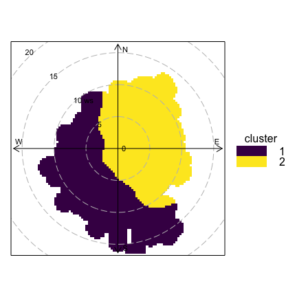

Now we have the data split by cluster we can separately apply a regression line through each to see if they really are different. The plot below shows the two cluster regression lines. Compared with the basic PM<sub>2.5</sub> vs. PM<sub>10</sub> plot shown earlier, it is not obvious at all there are two main regimes contained in the data — the overall regression is very good and it looks like there is only one main effect. However, if we carefully split the data using robust regression applied to the polar plot, followed by cluster analysis we can do a much better job of revealing the two different behaviours.

As shown in the plot below, cluster two has a slope of 0.98 i.e. nearly all the PM<sub>2.5</sub> is PM<sub>10</sub>. However, cluster 1 has a slope of 0.49 i.e. *half* of cluster 2. What this analysis shows is how it is possible to reveal hidden behaviours in the data that would otherwise be missed.

What this approach demonstrates is how it is possible to identify and extract different behaviours in the data. For a fuller analysis, it might be useful to use the clusters identified and then link the results with other data e.g. sulphate and nitrate data to explore the composition in more detail.

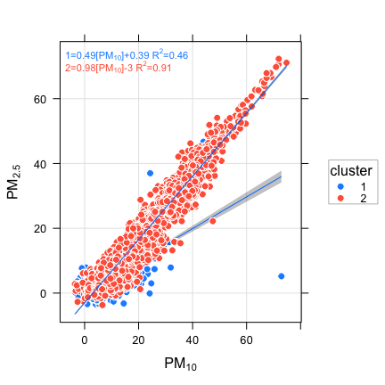

```r
scatterPlot(
  clust$data, x = "pm10", y = "pm2.5", group = "cluster",
  fill = c("dodgerblue", "tomato"), col = "white", pch = 21,
  linear = TRUE
)
```

> **A useful exercise is to try and do a better job of the scatter plot shown above using `ggplot2`. The plot might be clearer for example if each cluster plot was shown in its own panel**

Finally, in **openair** is it easy to plot the relationship between PM<sub>2.5</sub> and PM<sub>10</sub> and fit a linear regression model by using the inbuilt ‘type’ option where it is easy to consider the relationship by wind sector. Now it is possible to unpick things more. For easterly winds it seems that almost all the PM<sub>10</sub> is in the form of PM<sub>2.5</sub> (likely dominated by small sulphate / nitrate aerosol). The relationship is also strong for these wind sectors (as seen by the r<sup>2</sup> value). For other wind sectors the relationships are less good and eh slope value lower.

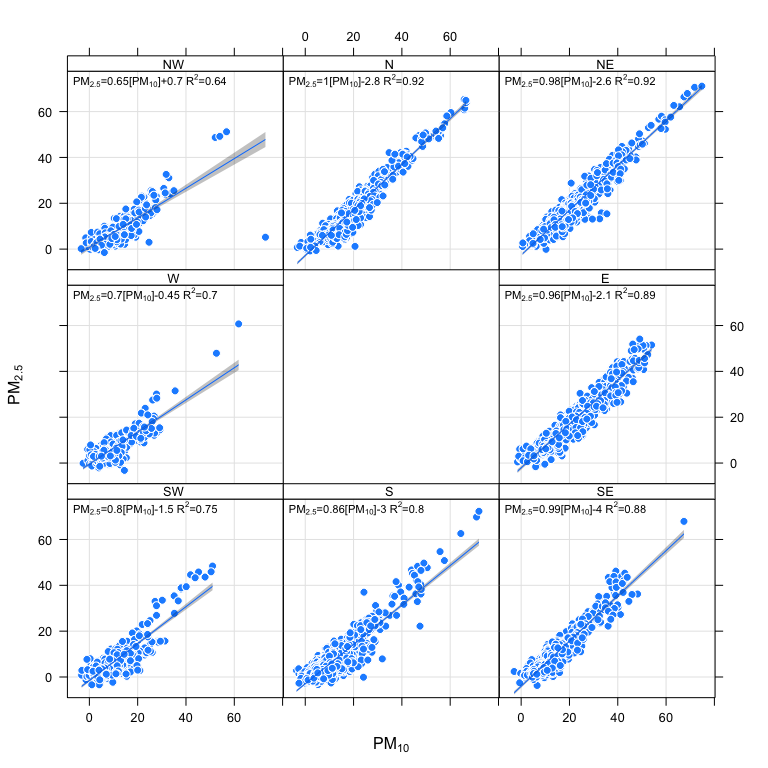

```r
scatterPlot(hc, x = "pm10", y = "pm2.5",
            fill = "dodgerblue", col = "white", pch = 21,
            type = "wd", linear = TRUE)
```

# 6 Polar plots on an interactive map

A developmental R package called `openairmaps` has been developed to plot bivariate polar plots on an interactive leaflet map. This package is not on CRAN but can be installed from GitHub:

```r
library(devtools)
install_github("davidcarslaw/openairmaps")
```

The function `polarMap` requires information on the site, latitude and longitude in addition to the usual information required by the `polarPlot` function. The package comes with some example data (`polar_data`) that can be used as a template for using different data.

```r
library(openairmaps)

glimpse(polar_data)
```

```
## Observations: 35,040
## Variables: 11
## $ date       <dttm> 2009-01-01 00:00:00, 2009-01-01 01:00:00, 2009-01-01…
## $ nox        <dbl> 130, 63, 76, 69, 61, 61, 61, 92, 57, 50, 59, 52, 61, …
## $ no2        <dbl> 48, 32, 36, 34, 31, 31, 29, 42, 32, 32, 34, 32, 34, 4…
## $ site       <chr> "London Marylebone Road", "London Marylebone Road", "…
## $ latitude   <dbl> 51.52253, 51.52253, 51.52253, 51.52253, 51.52253, 51.…
## $ longitude  <dbl> -0.154611, -0.154611, -0.154611, -0.154611, -0.154611…
## $ site.type  <chr> "Urban traffic", "Urban traffic", "Urban traffic", "U…
## $ wd         <dbl> 58.92536, 74.46675, 30.00000, 45.00000, 70.00000, 46.…
## $ ws         <dbl> 2.066667, 1.900000, 1.550000, 2.100000, 1.500000, 2.1…
## $ visibility <dbl> 5000.000, 4933.333, 5000.000, 4900.000, 5000.000, 600…
## $ air_temp   <dbl> 0.8666667, 0.8666667, 0.8000000, 0.8500000, 0.8666667…
```

Plot an interactive map.

```r
polarMap(polar_data, latitude = "latitude",
         longitude = "longitude",
         type = "site")
```

[interactive chart not shown]

Or with a different base map (there are many!).

```r
polarMap(polar_data, latitude = "latitude",
         longitude = "longitude",
         type = "site",
         provider = "Stamen.Toner")
```

> **See if you can plot a selection of Spanish sites in this way. You will need to link air quality data, site meta data (latitude and logitude) and meteorological data. It would be interesting for example to consider concentrations of PM<sub>2.5</sub>, PM<sub>10</sub> or a sub-component of PM.**

# References

Carslaw, D. C., and S. D. Beevers. 2013. “Characterising and Understanding Emission Sources Using Bivariate Polar Plots and K-Means Clustering.” *Environmental Modelling & Software* 40 (0): 325–29. https://doi.org/10.1016/j.envsoft.2012.09.005.

Carslaw, D. C., S. D. Beevers, K. Ropkins, and M. C. Bell. 2006. “Detecting and Quantifying Aircraft and Other on-Airport Contributions to Ambient Nitrogen Oxides in the Vicinity of a Large International Airport.” *Atmospheric Environment* 40 (28): 5424–34.

Grange, Stuart K, Alastair C Lewis, and David C Carslaw. 2016. “Source Apportionment Advances Using Polar Plots of Bivariate Correlation and Regression Statistics.” *Atmospheric Environment* 145. Pergamon: 128–34.

Uria-Tellaetxe, I, and D. C. Carslaw. 2014. “Conditional Bivariate Probability Function for Source Identification.” *Environmental Modelling & Software* 59: 1–9. https://doi.org/10.1016/j.envsoft.2014.05.002.